# Regression Analysis of Baseball Team Performance

Abdellah AitElmouden | Gabriel Abreu | Jered Ataky | Patrick Maloney

2/12/2021

## Abstract

To see how regression will help us evaluate baseball team performance, this project is designed to explore whether a teams success in any given season can be predicted or explained by any number of statistics in that season. Our goal is to build a multiple linear regression model on the training data to predict the number of wins for the team. we will explore, analyze and model a historical baseball data set containing approximately 2200 records. Each record represents a professional baseball team from the years 1871 to 2006 inclusive, and the data include the performance of the team for the given year, with all of the statistics adjusted to match the performance of a 162 game season.

While correlation does not imply causation, it is suggested that a focus on some of the variables such as single hits or triple or more hits to the exclusion of doubles might be worth pursuing. Also the data suggests that a focus on home runs allowed may not be worth giving up a number of more normal hits.

## Introduction

Because baseball is so numbers-heavy, there are many different statistics to consider when searching for the best predictors of team success. There are offensive statistics (offense meaning when a team is batting) and defensive statistics (defense meaning when a team is in the field). These categories can be broken up into many more subcategories. However, for the purpose of the this project we will use the available data to build a multiple linear regression model on the training data to predict the number of wins for the team.

To see how regression will help us predict the number of wins for the team, we actually don’t need to understand all the details about the game of baseball, which has over 100 rules. Here, we distill the sport to the basic knowledge one needs to know how to effectively attack the data science problem. The goal of a baseball game is to score more runs (points) than the other team. Each team has 9 batters that have an opportunity to hit a ball with a bat in a predetermined order. After the 9th batter has had their turn, the first batter bats again, then the second, and so on. Each time a batter has an opportunity to bat, we call it a plate appearance (PA). At each PA, the other team’s pitcher throws the ball and the batter tries to hit it. The PA ends with an binary outcome: the batter either makes an out (failure) and returns to the bench or the batter doesn’t (success) and can run around the bases, and potentially score a run (reach all 4 bases). Each team gets nine tries, referred to as innings, to score runs and each inning ends after three outs (three failures).

## Data Exploration

The dataset we will be using was provided in csv file. The files contain approximately 2200 records. Each record represents a professional baseball team from the years 1871 to 2006 inclusive. Each record has the performance of the team for the given year, with all of the statistics adjusted to match the performance of a 162 game season. The game statistics that will be used in this study are the following:

| VARIABLE NAME | DEFINITION | THEORETICAL EFFECT |
| --- | --- | --- |
| INDEX | Identification Variable (do not use) | None |
| TARGET_WINS | Number of wins | Outcome Variable |
| TEAM_BATTING_H | Base Hits by batters (1B,2B,3B,HR) | Positive Impact on Wins |
| TEAM_BATTING_2B | Doubles by batters (2B) | Positive Impact on Wins |
| TEAM_BATTING_3B | Triples by batters (3B) | Positive Impact on Wins |
| TEAM_BATTING_HR | Homeruns by batters (4B) | Positive Impact on Wins |
| TEAM_BATTING_BB | Walks by batters | Positive Impact on Wins |
| TEAM_BATTING_HBP | Batters hit by pitch (get a free base) | Positive Impact on Wins |
| TEAM_BATTING_SO | Strikeouts by batters | Negative Impact on Wins |
| TEAM_BASERUN_SB | Stolen bases | Positive Impact on Wins |
| TEAM_BASERUN_CS | Caught stealing | Negative Impact on Wins |
| TEAM_FIELDING_E | Errors | Negative Impact on Wins |
| TEAM_FIELDING_DP | Double Plays | Positive Impact on Wins |
| TEAM_PITCHING_BB | Walks allowed | Negative Impact on Wins |
| TEAM_PITCHING_H | Hits allowed | Negative Impact on Wins |
| TEAM_PITCHING_HR | Homeruns allowed | Negative Impact on Wins |
| TEAM_PITCHING_SO | Strikeouts by pitchers | Positive Impact on Wins |

The initial steps are to download the data and take a quick glimpse of the columns, their data types, number of columns, and rows. Based on initial observations, the data contains 2276 teams with a variety of baseball performance statistics.

At first glance, the column BATTING_HBP has numerous NA values that will need to be addressed before building a model. Figure 1 show summary statistics of the target wins. The noteworthy statistics are the average number of wins in a season is 81 games, the median number of wins in a season is 82 games, and the standard deviation is 16 games.

| **Characteristic** | **N = 2,276**<sup>1</sup> |
| --- | --- |
| TARGET_WINS | 81 (16) 82 0 146 |
| TEAM_BATTING_H | 1,469 (145) 1,454 891 2,554 |
| TEAM_BATTING_2B | 241 (47) 238 69 458 |
| TEAM_BATTING_3B | 55 (28) 47 0 223 |
| TEAM_BATTING_HR | 100 (61) 102 0 264 |
| TEAM_BATTING_BB | 502 (123) 512 0 878 |
| TEAM_BATTING_HBP | 59 (13) 58 29 95 |
| TEAM_BATTING_SO | 736 (249) 750 0 1,399 |
| TEAM_BASERUN_SB | 125 (88) 101 0 697 |
| TEAM_BASERUN_CS | 53 (23) 49 0 201 |
| TEAM_FIELDING_E | 246 (228) 159 65 1,898 |
| TEAM_FIELDING_DP | 146 (26) 149 52 228 |
| TEAM_PITCHING_BB | 553 (166) 536 0 3,645 |
| TEAM_PITCHING_SO | 818 (553) 814 0 19,278 |

<sup>*1*</sup> Mean (SD) Median Minimum Maximum

By examining the target wins variable in detail, there is a clear guideline of how many wins each team should approximately win. Most teams will likely win the average number of games (81), but there will be some variability from the average with some teams winning more or less than 81 games.

The other variables also play an important role in understanding the data. In Figure 1, summary statistics are presented for all the variables. it is sufficient in getting the gist of each variable’s distribution. For example, the average Base Hits by batters per team is 1469 with the minimum base hits at 891 and maximum base hits at 2554. Remember that the dataset contains baseball statistics on 2276 teams. Missing values were excluded from the summary and they will be dealt with in the data preparation section of this report.

A quick look at Figure 2 will reveal the distribution of the target wins. The distribution is approximately normal with a majority of the target wins falling in the center of the distribution.The approximate normal distribution is confirmed by the QQ plot below the distribution plot. Most of the target wins fall on the line in the QQ plot with some data points diverging at the ends. This indicates possibility of outliers where some teams are winning more games or losing more games than what is expected in the normal range.In the boxplot, there are points that fall outside the whiskers which confirms our suspicions of outliers seen in the QQ plot.

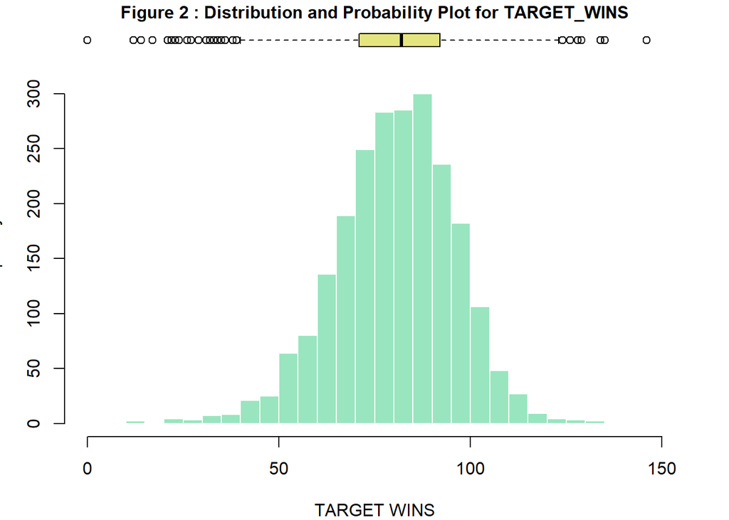

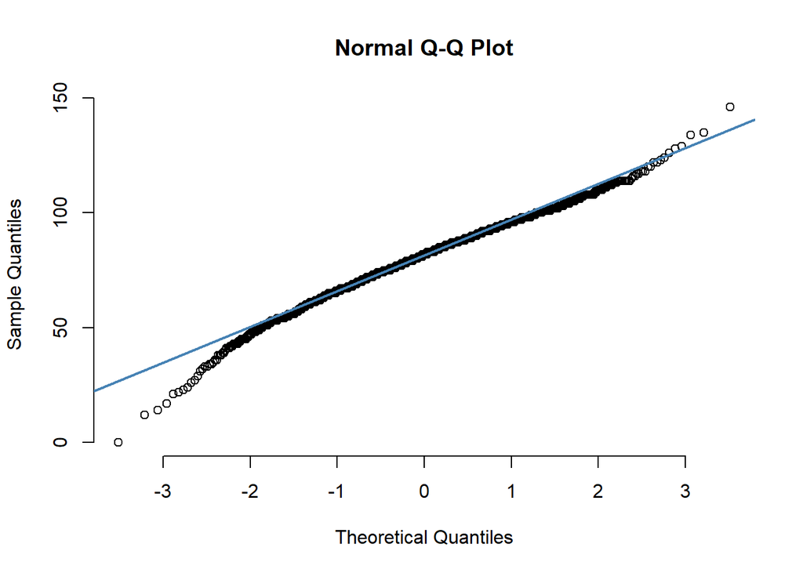

Now in order to build our models properly It’s worth exploring for other columns with NA values.

| Columns_w_NA | Percent_NA |
| --- | --- |
| team_batting_so | 4.481547 |
| team_baserun_sb | 5.755712 |
| team_baserun_cs | 33.919156 |
| team_batting_hbp | 91.608084 |
| team_pitching_so | 4.481547 |
| team_fielding_dp | 12.565905 |

### Outliers

The following diagram shows the outliers for all the variables, both dependent and independent.

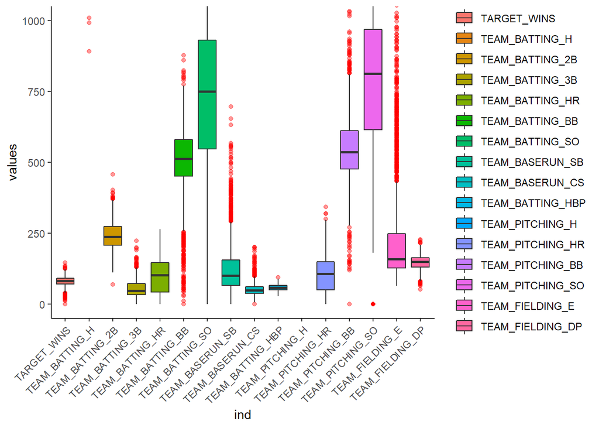

As we can see from the graph only 4 of the 16 variables are normally or close to normally distributed. the other 12 variables have a significant skew. The response variable Target_wins seems to be normally distributed. Batting_Hr, Batting_SO and Pitching_HR are bi-modal. 10 of the 16 variables have a minimum value of 0. This is not a major concern as the total % of 0 in each column is less than 1%. The variables Batting_BB, Batting_CS, Baserun_SB, Pitching_BB and Fielding_E have a significant number of outliers.

### Correlations among predictors and Variable Selection

| term | TARGET_WINS |
| --- | --- |
| INDEX | -0.02105643 |
| TEAM_BATTING_H | 0.38876752 |
| TEAM_BATTING_2B | 0.28910365 |
| TEAM_BATTING_3B | 0.14260841 |
| TEAM_BATTING_HR | 0.17615320 |
| TEAM_BATTING_BB | 0.23255986 |
| TEAM_BATTING_SO | -0.03175071 |
| TEAM_BASERUN_SB | 0.13513892 |
| TEAM_BASERUN_CS | 0.02240407 |
| TEAM_BATTING_HBP | 0.07350424 |
| TEAM_PITCHING_H | -0.10993705 |
| TEAM_PITCHING_HR | 0.18901373 |
| TEAM_PITCHING_BB | 0.12417454 |
| TEAM_PITCHING_SO | -0.07843609 |
| TEAM_FIELDING_E | -0.17648476 |
| TEAM_FIELDING_DP | -0.03485058 |

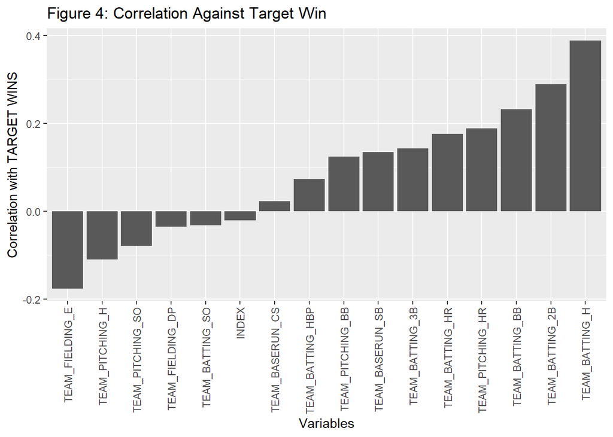

Before entirely excluding variables, it is a good idea to transform the data by fixing missing values or combining variables and reexamine the viability of those variables for predicting wins.

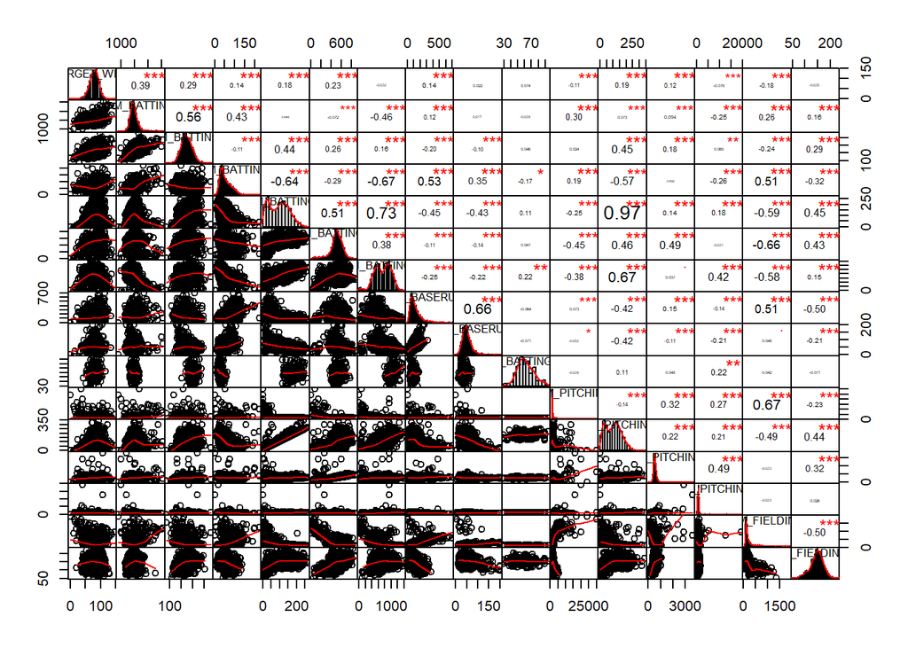

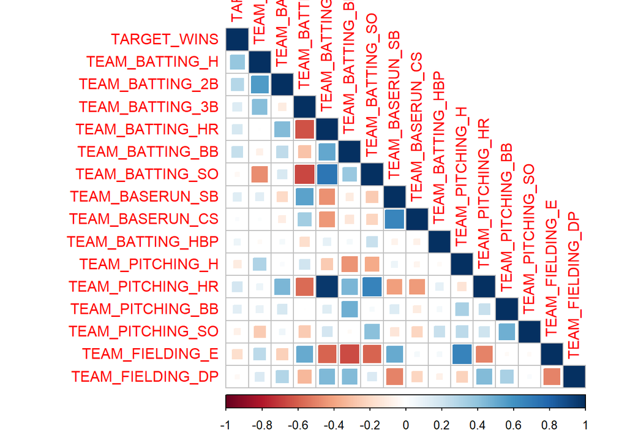

## Data Preparation

Missing values need to be handled before building models.They can be handled by either dropping the records, dropping the entire variable, or imputation. In this case, it was determined that Batters hit by pitch variable should be dropped altogether prior to model building because it has too many missing values to properly impute.All other variables with missing values will be considered for the model because a majority of the records are not missing.These variables will be imputed.

First we will remove Batting_HBP (Hit by Pitch) which has 92% missing values.

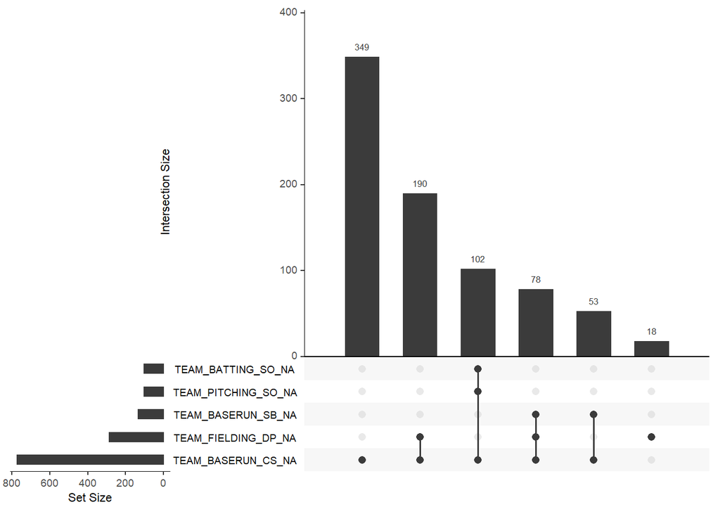

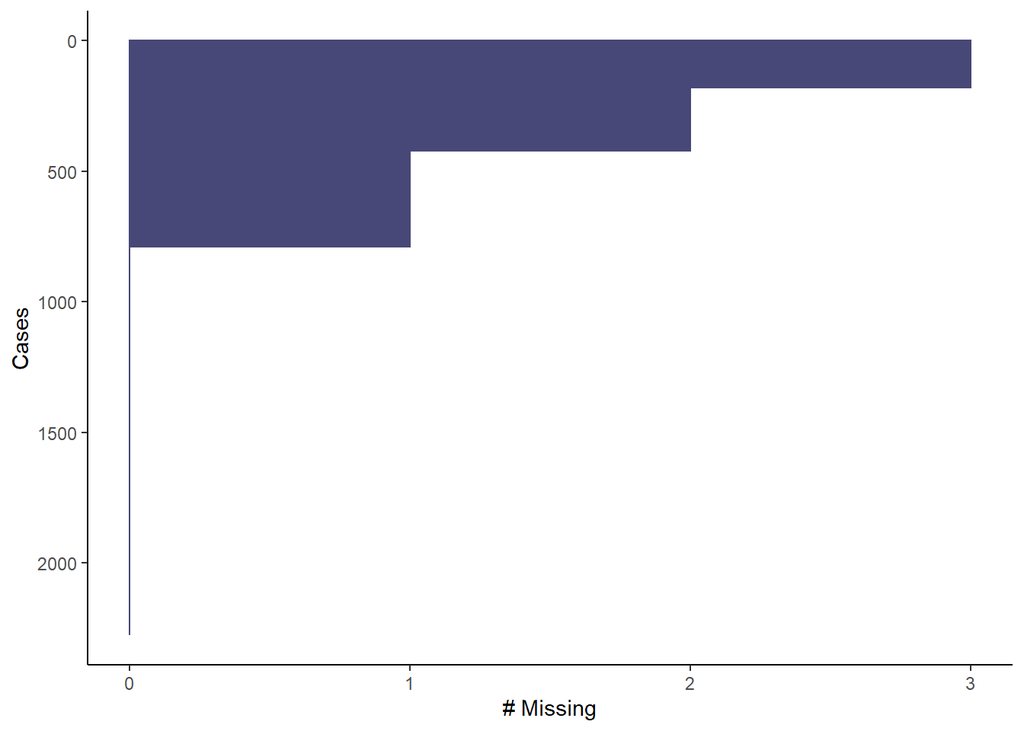

When it comes to fixing missing values,there are several methods at our disposal. The first technique is to fill the missing values with the mean values of each variable. We’ll use the Hmisc R Package to fill the missing data with the mean, most of the time, mean imputation will lead to good results. The same procedure will be used for the other variables with missing values in Model 2 but by using the Median instead of the mean

## Build Models

### MODEL 1: MEAN FULL MODEL

This is a full model containing all the variables with the meanusred for missing values. This is a good starting model to determine how well each variable helps predict wins. The mean is generally an adequate guess for missing values. In this model, no selection technique is used. All variables are manually included.

To the that we used the Hmisc R package to imputes missing value using user defined statistical method (mean in our case)

```
##
## Call:
## lm(formula = TARGET_WINS ~ TEAM_BATTING_H + TEAM_BATTING_2B +
##     TEAM_BATTING_3B + TEAM_BATTING_HR + TEAM_BATTING_BB + TEAM_BATTING_SO +
##     TEAM_BASERUN_SB + TEAM_BASERUN_CS + TEAM_PITCHING_H + TEAM_PITCHING_HR +
##     TEAM_PITCHING_BB + TEAM_PITCHING_SO + TEAM_FIELDING_E + TEAM_FIELDING_DP,
##     data = train_model1)
##
## Residuals:
##     Min      1Q  Median      3Q     Max
## -35.113  -7.633  -0.018   7.324  45.214
##
## Coefficients:
##                   Estimate Std. Error t value Pr(>|t|)
## (Intercept)      59.237509   6.113895   9.689  < 2e-16 ***
## TEAM_BATTING_H   -0.002070   0.005441  -0.380 0.703633
## TEAM_BATTING_2B  -0.023765   0.008808  -2.698 0.007034 **
## TEAM_BATTING_3B   0.168568   0.018723   9.003  < 2e-16 ***
## TEAM_BATTING_HR   0.321816   0.055324   5.817 6.98e-09 ***
## TEAM_BATTING_BB   0.093055   0.018164   5.123 3.30e-07 ***
## TEAM_BATTING_SO  -0.049966   0.008917  -5.603 2.40e-08 ***
## TEAM_BASERUN_SB   0.081187   0.006161  13.178  < 2e-16 ***
## TEAM_BASERUN_CS  -0.059350   0.014616  -4.061 5.09e-05 ***
## TEAM_PITCHING_H   0.025458   0.002263  11.251  < 2e-16 ***
## TEAM_PITCHING_HR -0.216833   0.052137  -4.159 3.33e-05 ***
## TEAM_PITCHING_BB -0.060526   0.016914  -3.578 0.000354 ***
## TEAM_PITCHING_SO  0.028051   0.007993   3.509 0.000459 ***
## TEAM_FIELDING_E  -0.084678   0.005292 -16.001  < 2e-16 ***
## TEAM_FIELDING_DP -0.120255   0.012485  -9.632  < 2e-16 ***
## ---
## Signif. codes:  0 '***' 0.001 '**' 0.01 '*' 0.05 '.' 0.1 ' ' 1
##
## Residual standard error: 10.96 on 1975 degrees of freedom
##   (286 observations deleted due to missingness)
## Multiple R-squared:  0.3858, Adjusted R-squared:  0.3814
## F-statistic: 88.61 on 14 and 1975 DF,  p-value: < 2.2e-16
```

[output not shown]

### MODEL 3: knn Imputation

Building the stepwise regression model with knn imputed values

|  | nvmax | RMSE | Rsquared | MAE | RMSESD | RsquaredSD | MAESD |
| --- | --- | --- | --- | --- | --- | --- | --- |
| 1 | 2 | 13.78629 | 0.2369186 | 10.88590 | 0.5342421 | 0.05379285 | 0.3776769 |
| 2 | 3 | 13.41253 | 0.2813850 | 10.64833 | 0.5938786 | 0.05934855 | 0.3933052 |
| 3 | 4 | 13.20383 | 0.3043986 | 10.50887 | 0.6602951 | 0.06302875 | 0.4752311 |
| 4 | 5 | 13.11250 | 0.3142211 | 10.40823 | 0.6696246 | 0.06414349 | 0.4666043 |
| 5 | 6 | 13.07002 | 0.3183961 | 10.33110 | 0.7145490 | 0.06590788 | 0.4988121 |
| 6 | 7 | 13.03534 | 0.3221374 | 10.25802 | 0.7205747 | 0.06662433 | 0.4576259 |
| 7 | 8 | 13.03959 | 0.3215716 | 10.24853 | 0.6973934 | 0.06304310 | 0.4335302 |
| 8 | 9 | 13.11905 | 0.3141521 | 10.26439 | 0.8023599 | 0.07107989 | 0.4434459 |
| 9 | 10 | 13.16507 | 0.3077004 | 10.29839 | 0.7586543 | 0.06167526 | 0.4134993 |
| 10 | 11 | 13.25277 | 0.3001718 | 10.34796 | 0.8177629 | 0.06538408 | 0.4193269 |

[output cut: 2 more lines]

```
##
## Call:
## lm(formula = TARGET_WINS ~ TEAM_BATTING_H + TEAM_BATTING_SO +
##     TEAM_BASERUN_SB + TEAM_PITCHING_HR + TEAM_FIELDING_E + TEAM_FIELDING_DP,
##     data = knn_data)
##
## Residuals:
##     Min      1Q  Median      3Q     Max
## -51.980  -8.547   0.148   8.398  63.362
##
## Coefficients:
##                   Estimate Std. Error t value Pr(>|t|)
## (Intercept)      35.203403   4.656401   7.560 5.80e-14 ***
## TEAM_BATTING_H    0.044863   0.002599  17.263  < 2e-16 ***
## TEAM_BATTING_SO  -0.010323   0.002091  -4.937 8.52e-07 ***
## TEAM_BASERUN_SB   0.037616   0.003784   9.942  < 2e-16 ***
## TEAM_PITCHING_HR  0.059940   0.007971   7.520 7.85e-14 ***
## TEAM_FIELDING_E  -0.027353   0.001582 -17.289  < 2e-16 ***
## TEAM_FIELDING_DP -0.117420   0.013006  -9.028  < 2e-16 ***
## ---
## Signif. codes:  0 '***' 0.001 '**' 0.01 '*' 0.05 '.' 0.1 ' ' 1
##
## Residual standard error: 13.13 on 2269 degrees of freedom
## Multiple R-squared:  0.3069, Adjusted R-squared:  0.3051
## F-statistic: 167.5 on 6 and 2269 DF,  p-value: < 2.2e-16
```

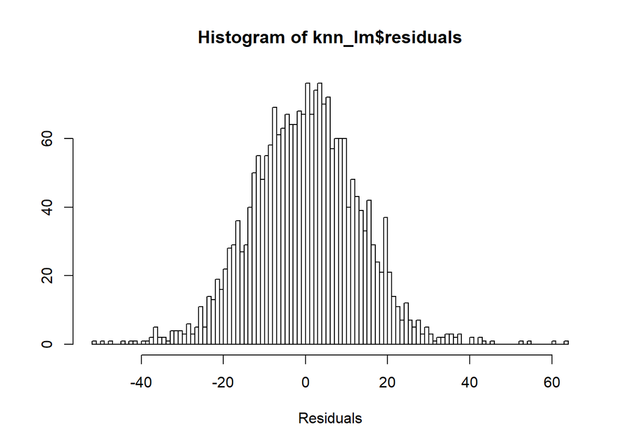

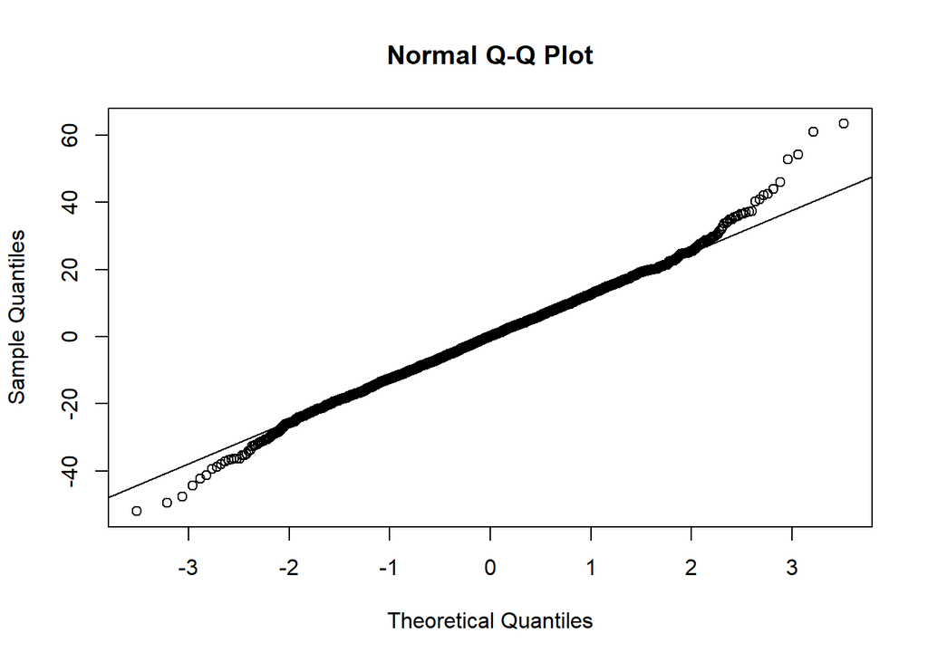

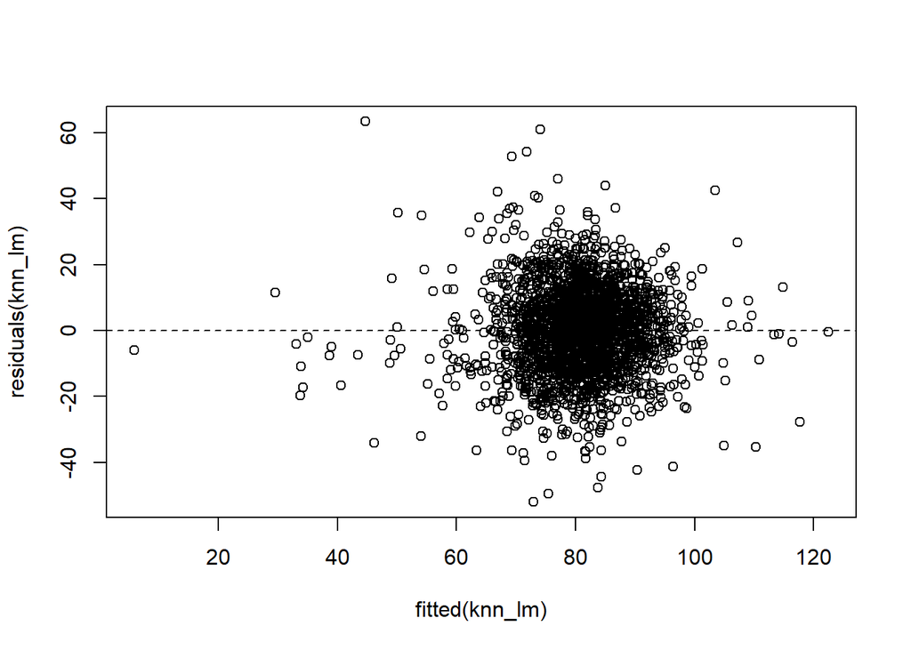

Now lets run the model…

## Select A Model

[output not shown]

Looking at the three models, we are going to use model 1, and the model is selected based on the criteria we had mentioned.

### Prediction

The test data should go to to the same cleaning process with the training data.

After, we have cleaned the test dataset, here’s how the result looks like on the table above which include the predicted values, and the prediction intervals.

```r
eval_model1 <- drop_na(eval_model1)
predict1 <- predict(model1, newdata = eval_model1, interval="prediction")
kable(predict1)
```

| fit | lwr | upr |
| --- | --- | --- |
| 60.07336 | 38.49515 | 81.65158 |
| 65.67460 | 44.11320 | 87.23601 |
| 71.23288 | 49.68348 | 92.78227 |
| 84.86087 | 63.31623 | 106.40550 |
| 103.93799 | 81.28573 | 126.59026 |
| 71.85566 | 50.14909 | 93.56223 |
| 72.34177 | 50.75179 | 93.93174 |
| 75.22567 | 53.67294 | 96.77841 |
| 70.76950 | 49.23281 | 92.30620 |
| 64.63909 | 43.08353 | 86.19464 |
| 83.07114 | 61.51171 | 104.63057 |
| 85.21038 | 63.63224 | 106.78852 |
| 82.79881 | 61.22043 | 104.37720 |
| 85.81195 | 64.21798 | 107.40592 |
| 74.96797 | 53.40346 | 96.53247 |
| 71.29929 | 49.76256 | 92.83602 |
| 76.99432 | 55.46692 | 98.52171 |
| 68.15789 | 46.58147 | 89.73432 |
| 86.08610 | 64.50586 | 107.66633 |
| 85.29403 | 63.73352 | 106.85453 |
| 82.19979 | 60.64507 | 103.75451 |
| 83.06310 | 61.51523 | 104.61096 |
| 70.06209 | 48.52136 | 91.60282 |
| 78.84225 | 57.29569 | 100.38881 |
| 86.07804 | 64.51782 | 107.63826 |
| 68.95160 | 47.39845 | 90.50475 |
| 82.72954 | 61.13728 | 104.32179 |
| 67.20395 | 45.60529 | 88.80262 |
| 91.75254 | 70.18634 | 113.31875 |
| 86.83842 | 65.30544 | 108.37141 |

[output cut: 198 more lines]

## Appendix

```r
knitr::opts_chunk$set(cache =TRUE)

# 0.  Librairies

library(corrplot)
library(tidyverse)
library(Hmisc)
library(PerformanceAnalytics)
library(corrplot)
library(mice)
library(gt)
library(DMwR)
library(caret)
library(bnstruct)
library(VIM)
library(corrr)
library(tidyverse)
library(gtsummary)
library(kableExtra)
```

```r
# 1. Data Exploration

## Import data

train_data <- read.csv("https://raw.githubusercontent.com/aaitelmouden/DATA621/master/Project1/moneyball-training-data.csv")
glimpse(train_data)


## Summary table

wins <- train_data %>% select(TARGET_WINS, TEAM_BATTING_H, TEAM_BATTING_2B, TEAM_BATTING_3B, TEAM_BATTING_HR, TEAM_BATTING_BB, TEAM_BATTING_HBP, TEAM_BATTING_SO, TEAM_BASERUN_SB, TEAM_BASERUN_CS, TEAM_FIELDING_E, TEAM_FIELDING_DP, TEAM_PITCHING_BB, TEAM_PITCHING_SO, TEAM_FIELDING_E, TEAM_FIELDING_DP)
table1 <- tbl_summary(wins,
          statistic = list(all_continuous() ~ "{mean} ({sd}) {median} {min} {max}"), missing = "no")
table1


## Create more variables

singles <- train_data$TEAM_BATTING_H - (train_data$TEAM_BATTING_2B + train_data$TEAM_BATTING_3B + train_data$TEAM_BATTING_HR)

train_data$TEAM_BATTING_SLG <- ((train_data$TEAM_BATTING_HR *4)+ (train_data$TEAM_BATTING_3B*3) + (train_data$TEAM_BATTING_2B*2)+ singles)/train_data$TEAM_BATTING_H
```

```r
## Plots

### Layout to split the screen
layout(mat = matrix(c(1,2),2,1, byrow=TRUE),  height = c(1,8))

####  Draw the boxplot and the histogram
par(mar=c(0, 3.1, 1.1, 2.1))
boxplot(train_data$TARGET_WINS ,main="Figure 2 : Distribution and Probability Plot for TARGET_WINS",cex.main=1, horizontal=TRUE , ylim=c(0,150), xaxt="n" , col=rgb(0.8,0.8,0,0.5) , frame=F)
par(mar=c(4, 3.1, 1.1, 2.1))
hist(train_data$TARGET_WINS , breaks=40 , col=rgb(0.2,0.8,0.5,0.5) , border=F , main="" , xlab="TARGET WINS", xlim=c(0,150))
```

```r
### qq plots

qqnorm(train_data$TARGET_WINS, pch = 1, frame = FALSE)
qqline(train_data$TARGET_WINS, col = "steelblue", lwd = 2)


max_obs <- 2276
batting_so_na <- ((102/max_obs) * 100)
baserun_sb_na <- (131/max_obs) * 100
baserun_cs_na <- (772/max_obs) * 100
batting_hbp_na <- (2085/max_obs) * 100
pitching_so_na <- (102/max_obs) * 100
fielding_dp_na <- (286/max_obs) * 100

df_percent_na <- data.frame(Columns_w_NA = c("team_batting_so", "team_baserun_sb", "team_baserun_cs", "team_batting_hbp", "team_pitching_so", "team_fielding_dp"), Percent_NA = c(batting_so_na, baserun_sb_na, baserun_cs_na, batting_hbp_na, pitching_so_na, fielding_dp_na))


### the largest islands in the world

gt_tbl <- gt(data = df_percent_na, )


### Show the gt Table

gt_tbl
```

```r
### Outlliers

ggplot(stack(train_data[,-1]), aes(x = ind, y = values, fill=ind)) +
  geom_boxplot(outlier.colour = "red",  outlier.alpha=.4) +
  coord_cartesian(ylim = c(0, 1000)) +
  theme_classic()+
  theme(axis.text.x=element_text(angle=45, hjust=1))


### Correlation

COR <- train_data %>%
  correlate() %>%
  focus(TARGET_WINS)
gt(COR)

COR %>%
  mutate(rowname = factor(term, levels = term[order(TARGET_WINS)])) %>%  # Order by correlation strength
  ggplot(aes(x = rowname, y = TARGET_WINS)) +
    geom_bar(stat = "identity") +
    ylab("Correlation with TARGET WINS") +
    xlab("Variables") + theme(axis.text.x = element_text(angle = 90, vjust = 0.5, hjust=1))+ ggtitle("Figure 4: Correlation Against Target Win")
```

```r
#### pairwise.complete.obs ignores NA values and computes correlation on complete observations
#### we might have to run these corrplots again after we handle the NA values

chart.Correlation(train_data[-c(1)], histograme=TRUE, method= "pearson", use="pairwise.complete.obs")

data.corr <- cor(train_data[-c(1)], use="pairwise.complete.obs")

corrplot(data.corr, type = "lower", method="square")

flattenCorrMatrix <- function(cormat, pmat) {
  ut <- upper.tri(cormat)
  data.frame(
    row = rownames(cormat)[row(cormat)[ut]],
    column = rownames(cormat)[col(cormat)[ut]],
    cor  =(cormat)[ut],
    p = pmat[ut]
    )
}

#### Eliminate INDEX from data frame
data_no_index <- train_data[-c(1)]

cor_matrix <- rcorr(as.matrix(data_no_index))

flattenCorrMatrix(cor_matrix$r, cor_matrix$P)
```

```r
#. 2 Data preparation

train_data <- train_data[-11]


par(mfrow=c(1,2))
gg_miss_upset(train_data,
              nsets = 5,
              nintersects = NA)
gg_miss_case(train_data)+
  theme_classic()


par(mfrow=c(1,2))
gg_miss_upset(train_data,
              nsets = 5,
              nintersects = NA)
gg_miss_case(train_data)+
  theme_classic()
```

```r
# 3. Build models

### MODEL 1: MEAN FULL MODEL

### Filling missing values with Mean using the impute package

train_model1 <- train_data
train_model1$TEAM_BATTING_SO[is.na(train_model1$TEAM_BATTING_SO)] = mean(train_model1$TEAM_BATTING_SO, na.rm=TRUE)
train_model1$TEAM_BASERUN_SB[is.na(train_model1$TEAM_BASERUN_SB)] = mean(train_model1$TEAM_BASERUN_SB, na.rm=TRUE)
train_model1$TEAM_BASERUN_CS[is.na(train_model1$TEAM_BASERUN_CS)] = mean(train_model1$TEAM_BASERUN_CS, na.rm=TRUE)
train_model1$TEAM_PITCHING_SO[is.na(train_model1$TEAM_PITCHING_SO)] = mean(train_model1$TEAM_PITCHING_SO, na.rm=TRUE)

model1 <- lm(TARGET_WINS ~
               TEAM_BATTING_H +   # Base Hits by batters (1B,2B,3B,HR)
               TEAM_BATTING_2B +  # Doubles by batters (2B)
               TEAM_BATTING_3B +  # Triples by batters (3B)
               TEAM_BATTING_HR +  # Homeruns by batters (4B)
               TEAM_BATTING_BB +  # Walks by batters
               TEAM_BATTING_SO +  # Strikeouts by batters
               TEAM_BASERUN_SB +  # Stolen bases
               TEAM_BASERUN_CS +  # Caught stealing
               TEAM_PITCHING_H +  # Hits allowed
               TEAM_PITCHING_HR + # Homeruns allowed
               TEAM_PITCHING_BB + # Walks allowed
               TEAM_PITCHING_SO + # Strikeouts by pitchers
               TEAM_FIELDING_E +  # Errors
               TEAM_FIELDING_DP,  # Double Plays
             data=train_model1)
summary(model1)

### Mean Square Error (MSE)

mean(model1$residuals^2)

layout(matrix(c(1,2,3,4),2,2)) # optional 4 graphs/page
plot(model1)
```

```r
### MODEL 2: MEDIAN WITH STEPWISE

train_model2 <- train_data

#### Filling missing values with Mean using the impute package

train_model2$TEAM_BATTING_SO[is.na(train_model2$TEAM_BATTING_SO)] = median(train_model2$TEAM_BATTING_SO, na.rm=TRUE)
train_model2$TEAM_BASERUN_SB[is.na(train_model2$TEAM_BASERUN_SB)] = median(train_model2$TEAM_BASERUN_SB, na.rm=TRUE)
train_model2$TEAM_BASERUN_CS[is.na(train_model2$TEAM_BASERUN_CS)] = median(train_model2$TEAM_BASERUN_CS, na.rm=TRUE)
train_model2$TEAM_PITCHING_SO[is.na(train_model2$TEAM_PITCHING_SO)] = median(train_model2$TEAM_PITCHING_SO, na.rm=TRUE)


model2 <- lm(TARGET_WINS ~
               TEAM_BATTING_H +   # Base Hits by batters (1B,2B,3B,HR)
               TEAM_BATTING_2B +  # Doubles by batters (2B)
               TEAM_BATTING_3B +  # Triples by batters (3B)
               TEAM_BATTING_HR +  # Homeruns by batters (4B)
               TEAM_BATTING_BB +  # Walks by batters
               TEAM_BATTING_SO +  # Strikeouts by batters
               TEAM_BASERUN_SB +  # Stolen bases
               TEAM_BASERUN_CS +  # Caught stealing
               TEAM_PITCHING_H +  # Hits allowed
               TEAM_PITCHING_HR + # Homeruns allowed
               TEAM_PITCHING_BB + # Walks allowed
               TEAM_PITCHING_SO + # Strikeouts by pitchers
               TEAM_FIELDING_E +  # Errors
               TEAM_FIELDING_DP,  # Double Plays
             data=train_model2)
summary(model1)

mean(model2$residuals^2)

layout(matrix(c(1,2,3,4),2,2)) # optional 4 graphs/page
plot(model2)
```

```r
### MODEL 3: kNN Imputation

train_data_impute <- select(train_data, -c(INDEX))


#### using default values

knn_data <- knnImputation(train_data_impute)

summary(knn_data)

train.control <- trainControl(method ='cv', number=10)

step.model <- train(TARGET_WINS ~., data = knn_data,
                    method = "leapSeq",
                    tuneGrid = data.frame(nvmax = 2:13),
                    trControl = train.control
                    )

step.model$results

step.model$bestTune

summary(step.model$finalModel)

coef(step.model$finalModel, 6)


knn_lm <- lm(formula = TARGET_WINS ~ TEAM_BATTING_H + TEAM_BATTING_SO + TEAM_BASERUN_SB + TEAM_PITCHING_HR + TEAM_FIELDING_E + TEAM_FIELDING_DP, data = knn_data)

summary(knn_lm)


hist(knn_lm$residuals, xlab = "Residuals", ylab = "", breaks=100)
qqnorm(knn_lm$residuals)
qqline(knn_lm$residuals)

plot(fitted(knn_lm), residuals(knn_lm))
abline(h=0, lty = 2)
```